# Zer da hizkuntza

# Hizkuntza zer den argi, garbi eta ezbairik gabe esaten duenik ere ez dakigu dagoen

- Zer da hizkuntza bat?
- Hizkuntza ikasten dugu? Ala beste zerbait gertatzen da? Zer?
- H1 eta beste H<sub>x</sub> guztiak berdin lortzen ditugu? Berdin lortzen dugu jakitea, alegia?
- Eta… berdin umetan edo nagusitan?
- Etxean ikasten badugu hizkuntza, eskolan zer egiten dugu? Zein alde dago batetik bestera?

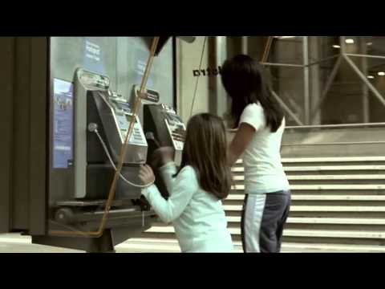

## Hizkuntza

- komunikazio tresna
- pentsatzeko tresna
- ikasteko tresna
- sortzeko tresna
- …
- Tresna?!??! 🤷

Erabaki behar dugu ea tresna den hizkuntza ala gu garen hizkuntzarenak.

Zein neurritan den hori, behintzat.

### Hizkuntza: komunikazio tresna

## Gizakion arteko hartu-emanak erregulatzeko eta kontrolatzeko

## Gizakiok hizkuntzaren erabileraz “orain” eta “hemen” egotea gaindi dezakegu animaliek ezin dezaketen moduan.

> Komunikatzea soilik ez, zer komunikatzen den ere kontuan izan bhear da. Partikulazki, lengoaiaren bitartez baino ezin daitekeena komunikatu

> – Tough, *El lenguage oral en la escuela*, 14. orr.

### Hizkuntza: pentsatzeko eta ikasteko tresna

## Hizkuntzaren bitartez mundua ezagutzen eta ulertzen dugu, hizkuntzak berak horretan laguntzen digu.

## Munduan eragiteko hizkuntza Jarduerak hizkuntzaren bitartez planifikatu, antolatu eta kontrolatu

> … lengoaiaren bitartez, amak umeari erakusten dizkio eraiki behar duen munduaren planu semantikoak. Errealitate gordina ez daiteke habitatu: zentzua eman behar zaio, zatitu, alor eta sailetan banatu behar da eta euren arteko bideak eta hartu-emanak eraiki behar dira, batetik bestera igarotzeko. Nahitanahiez, haurrak eraiki behar du bere bizi-gunea, errealitatearen jabe egin behar baita. Baina latza litzateke arkitektura bera ere asmatu beharra. (…) Hizkuntzari eskerrak, zure esperientzien menpekoa ez zara soilik, beste guztien eserientziak ere baliatu ditzakezu.

> Hizkuntzak, norbanakoari Mundua eraikitzen uzteaz gain, horren jabe egiten ere uzten du. … Amak ez dio soilik ordena ezartzen mundu objektiboari, haurraren subjekturik gabeko subjetibotasunari ere ezartzen dio … Lengoaia, besteekiko komunikatzeko bitarteko legez hasten dena, umea bere buruarekin komunikatzeko bitarteko bilakatzen da, egintzak antolatzen lagunduaz. Adimena eraikitzeko berebiziko garrantzia du hizkuntzaren funtzio antolatzaileak.

> – Marina (1993), El mundo y el lenguaje, *Teoría de la inteligencia creadora*

Ideion adibide argigarri batzuk, ingelesetik ekarrita, Wells-en (1988) liburuan:

> Elizabeth, lau urteko haurra, amari so dago, beheko suko errautsak pala batekin batu eta balde batera zelan botatzen dituen ikusten.

> E: Zertarako egiten duzu hori?  
> M: Batzen eta kanpora eramaten babil, gero aitak ortuan zabaltzeko  
> E: Eta zertarako botako ditu ortuan?  
> M: Lurra ontzeko.  
> E: Eta horrela ondo hasiko dira landareak?  
> M: Bai.  
> E: Eta hori, zergatik?  
> M: Gogoan duzu aurrekoan azaldu nizula zuk denetarik jan behar duzula, arrautzak eta azak eta porru-patatak neska handia hazteko?  
> E: Bai.  
> M: Ba, landareek ere denetarik behar dute. Eta haiei ondo doakienetariko bat errautsa da.

> – Wells, (1988, 79 or.)

> James, hiru urte eta erdi duela, etxeko lorategian jolasean izan da. Amak etxera eraman nahi du galtzerdi eta zapata lokastuak aldatzera, baina, etxera sartzeko dagoela, txoria ikusten du:

> M: Ea. Horrela, zapata bat jantzita.  
> J: Txoria ikusten dut.  
> M: Zer ikusi, bihotza??  
> J: Txoritxoa ikusten dut.  
> M (ahopeka): Hor? Kanpoan?  
> J (atzamarraz erakutsiaz eta ahopela):Bai. Ikusten dut  
> [Biek ahopeka segitzen dute]  
> M: Ezer jaten dabil?  
> E: Ez.  
> M: Han doa… -txoritxoa paperezko bortsa batera doa eta zati batzuk hartzen ahalegintzen da- Oh, hor jateko apur bat dauka. Eta uste dut zatitxu batzuk hartuko dituela kabia egiteko. James, egon apur batean banoa…

> Jamesek hurbilagotik ikustera irten nahi du, baina momentu horretantxe txoritxoa hegaz hasten da.

> J: Txoritxoa joan egin da.  
> M (tonu normalean): Joan egin da?  
> J: Bai.

> – Wells, (1988, 81 or.)

> Simonek, lau urte eta bederatzi hilekoa, sagarra jan berri du eta haziekien batu ditu. Amari azaltzen dio zer egin litekeen horiekin.

> S: Hazia haz daiteke. Batzuk erein ahal ditugu. Sagar-hazi askotxu ditut eta, gehiago lortzen baditut, aitak eta biok egunen batean irten ahal gara, euririk egiten ez duen egunen batean, eta haziak erein genitzake. Edo nik erein ahal ditut bihar.

> – Wells, (1988, 81 or.)

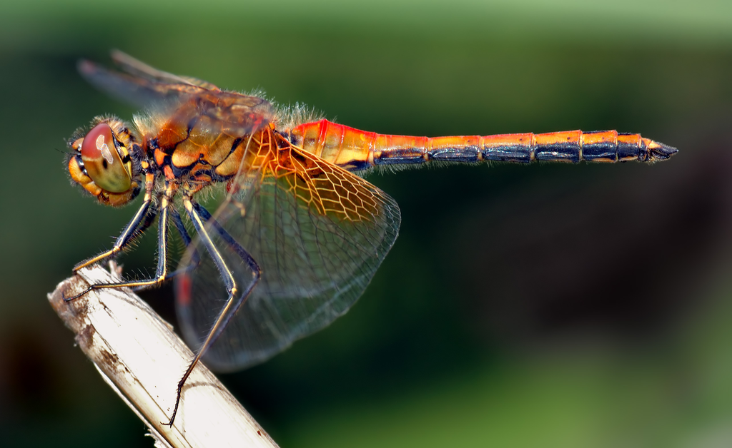

- Zer eragiten dizu?
- … eta … izena zelan du?

### Hizkuntza: sortzeko tresna

## Hizkuntza erabili behar dugu adierazpenerako honakoak egiten ditugunean:

- Poemak
- Ipuinak
- kantak
- Ahokorapiloak
- Igarkizunak
- Hitz-jokoak

Berba huts eta gardenean oinarritzen diren kultur adierazpenak: bertsolaritza, errefrauak…

- *Ago ixiletik ez da ezer jakiten*

Eta gaztelaniaz,

- *Hombre refranero, majadero y embustero*

# Lehenengo ariketa: Hausnarketa

## Hurrengo puntuak taldeko hausnarketa bat egiteko erabili

Ikuspegi bikoitz batetik: norbanako legez eta Haur Hezkuntzako irakasle(gai) legez

- Gure hizkuntzei zein erabilera ematen diegu? (H1/H2/…) Nahi duguna nahi dugun moduan adierazteko balio digute H<sub>x</sub> guztiek?
- Irakasle gisa, zer garrantzia du ikasgelan hizkuntza aberatsa eta adierazkorra erabiltzea?
- Zer egin dezakegu hizkuntzaren erabilera bizi eta adierazkorraz ere adierazteko?
- Eta HHko gelan zein neurritan ematen zaie aukera umeei hurrengoak egiteko?
  - Ideiak ahalik eta ondoen formulatzeko, haien ekintzak justifikatzeko, esperimentatzen dutenaz hausnartzeko eta arrazonatzeko, argumentatzeko, azalpenak emateko, planifikatzeko, kontatzeko… ?
  - Haien mundu emozionalarekin konektatu eta sentimenduak eta emozioak hitzez adierazteko, haietaz kontzientzia hartzeko, emozioak eta sentimenduak konpartitzeko?
  - Hizkuntzarekin jolasteko, sortzeko eta gozatzeko?
- Irakasle gisa, zelako esperientziak eskaini ahal dizkiogu ume guztiei hizkuntzaren erabilerari dagokionean? Zelan erabili dezakegu elkarrizketa? Zer-nolako estrategiak erabili ditzakegu?

# Eskolaren eginkizuna hizkuntza arloan

Ikasleen hizkuntza-komunikaziorako gaitasuna garatzen laguntzea, hizkuntza eraginkortasunez erabil dezaten euren bizitzako egoera eta behar guztietan.

## Hizkuntza HHko curriculumean

Hizkuntza beste hizkuntzekin (musika-hizkuntza, gorputz- hizkuntza, arte-hizkuntza, …) eremu bakarrean bilduta ulertzen izan da:

> **8. artikulua Hizkuntza-esparrua.**
> 1. Hezkuntza-sistemaren helburua da haur guztien hizkuntza- eta komunikazio-trebetasunak kulturarteko ikuspegi eleaniztun batetik abiatuta garatzea. Horretarako, bi hizkuntza ofizialak ikastea sustatuko da, haurren familien hizkuntza kontuan hartuta, eta euskara sustatuko da komunikazio-hizkuntzatzat. Haurrak atzerriko hizkuntza bat ikasten eta erabiltzen hasteko irakaskuntza ere eman ahal izango dute ikastetxeek.
> 2. Hizkuntzen irakaskuntza eta ikaskuntza antolatzeko eta hizkuntzak tratatu eta erabiltzeko irizpideak haurren eta haien ingurunearen errealitate soziolinguistikoa kontuan hartuta zehaztuko dira, ikastetxeen autonomiaren esparruan. Indarrean den legediarekin bat etorrita, ikastetxeak hartzen dituen erabaki guztiak ikastetxearen Hezkuntza-proiektuaren barruko Hizkuntza-proiektuan zehaztu behar dira, zeinetan planifikatu behar baitira haurrek hizkuntzak ikasteko, erabiltzeko eta hizkuntzekiko jarrera positiboa garatzeko bideak. Hezkuntzaren arloko eskumena duen sailak Hizkuntza-proiektuon jarraipena eta ebaluazioa egingo du.
> 3. Ikastetxean bertan garatzen diren jardueretan eta kanpo-proiekzioko jardueretan adierazpidea euskara izatea sustatu eta ziurtatuko da.
> 4. Komunikazio- eta hizkuntza-konpetentziaren garapena zeharka landuko da curriculumeko arloen testuinguruan, eta, horretarako, hizkuntza testuinguruan kokatutako egoera funtzional, atsegin eta esanguratsu batean ikastea eta irakastea bermatu behar da.
> 5. Euskal Hezkuntza Sisteman berandu sartzen diren ikasle atzerritarrak hartzeko eta haiei hizkuntza-arreta emateko, ikasle horien inklusioa ahalbidetuko duten prestakuntza-programa integralak beharko dira.
> 6. Hezkuntzaren arloko eskumena duen sailak irakasleak prestatzeko eta trebatzeko plan bat egingo du, hizkuntzen esparruan hizkuntza- eta metodologia-konpetentziak hobetzeko.

> — Hezkuntza Saila. (2023). 75/2023 DEKRETUA, maiatzaren 30ekoa, Haur Hezkuntzaren curriculuma zehaztu eta Euskal Autonomia Erkidegoan ezartzekoa. *Euskal Herriko Agintaritzaren Aldizkaria*, 109, 1–41.

### Aro kritikoa

- Zer da?
- Aro kritikoa bat da hizkuntza guztientzat?
- Aro kritikoa bat da hizkuntza trebetasun (irakurmena, ahozkera, ulermena, etab.) guztientzat?
- Aro kritikoaren ondoren, posible ote da hizkuntza bat besteek bezala eskuratzea?

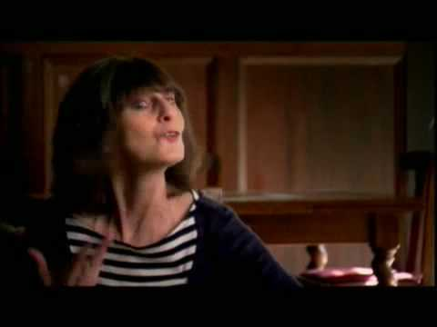

Selinkerren ustez (Selinker, 1972) beste hizkuntza batean arrakasta osoa lortzen da jatorrizko hiztun bat bezala bezain ongi hitz egiterakoan, ados?

CPH, ([Critical Period Hypothesis](https://en.wikipedia.org/wiki/Critical_period_hypothesis)): Penfield & roberts (1959)

Autore askok ikuskera desberdinak hartu dituzte gaiaren gainean, baina aro kritikoren bat askok identifikatu dute. Desberdin, baina identifikatu, horrela honela laburbil daitezke esanguratsuenak:

- Penfield & Roberts (1959): 9 urte
- Lenneberg (1967): pubertaroa
- Krashen (1973): 5 urte

# Bigarren ariketa

## Irakurri Barreña (1994) [artikulua](https://zientzia.eus/artikuluak/chomskyren-arauak-eta-hizkuntz-jabekuntza/) eta erantzun dagozkion itemak (taldeka, irakasleak pasatuko dizun URLan).

1. Zelan ulertzen dute sortzaileek delako Gramatika Unibertsala?
2. Zelan liteke gramatikaren eta sintaxiaren jabekuntza bideratzen duen ahalmena gizakiok genetikoki daukagula esatea?
3. Zein motatako hornia da giza hizkuntzaz jabetzea ahalbideratzen duena?
4. Baina zelan izan liteke haurrak bere ama-hizkuntzaz jabetzea, jasotzen duen hizkuntz esperientzia mugatua eta okerrez betea bada?
5. Zer da Gramatika Unibertsala?
6. Zertzuk dira hizkuntzaren parametroak? Adibideak eman.
7. Nola ikasten du haurrak hizkuntza? Entseiu / errakuntza? Hurrenkerarik bada?
8. Zein adinarekin hasten da haurra ergatiboa edo pluralaren komunztadura erabiltzen? Eta autozuzentzeko gaitasuna?
9. Zertan oinarritzen da hizkuntza jabekuntzaren garapena?

**Erreferentziak**

Barreña, A. (1994, ekainak 1). Chomskyren arauak eta hizkuntz jabekuntza. *Elhuyar aldizkaria*, 1994, 25–31.

Gutierrez Mangado, M. J., & Ezeizabarrena Segurola, M. J. (2022). *Hotsetik hitzera Nola bereganatzen dute hizkuntza haur euskaldunek?* Erein Argitaletxea.

Marina, J. A. (1993). Teoría de la inteligencia creadora. Editorial Anagrama.

Perales, J. (2004). Euskara helduaroan ikasteko motibazioa: Hainbat gogoeta. *Uztaro: giza eta gizarte-zientzien aldizkaria*, 50, 23–43.

Wells, Gordon. (1988). *Aprender a leer y escribir*. Laia.